# Econ_HW4

Arash Barmas

2/28/2019

R Exercise A Question 1 We have an MA(1) model Simulate and plot 250 obser- vations of the MA(1)

1 a)

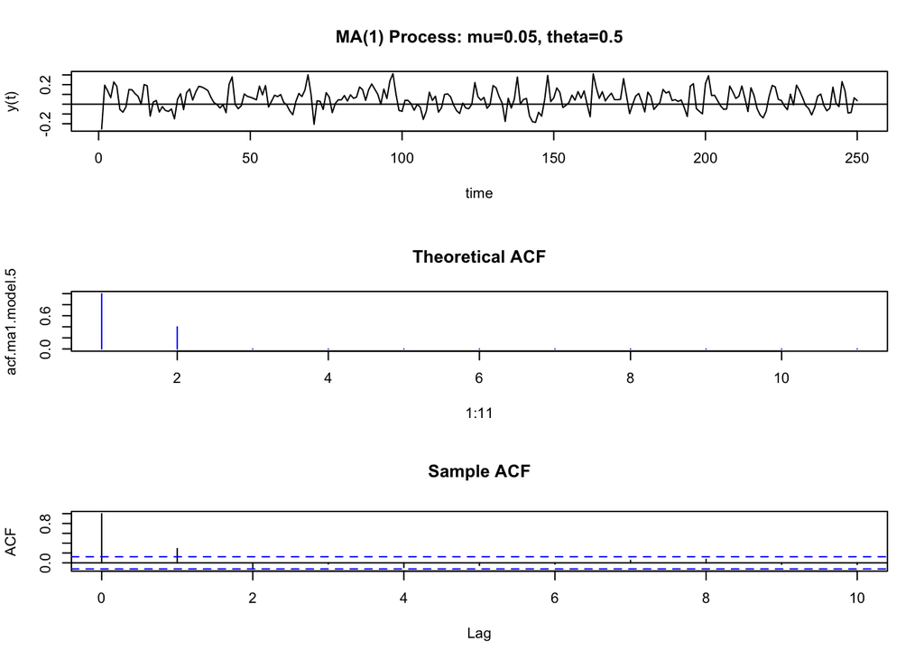

```r
theta = 0.5
mu    = 0.05
ma1.model.5 = list(ma=theta)

set.seed(123)
ma1.sim.5 = mu + arima.sim(model=ma1.model.5, n=250,
                         innov=rnorm(n=250, mean=0, sd=0.1))

acf.ma1.model.5 = ARMAacf(ma=theta, lag.max=10)
par(mfrow=c(3,1))
    plot(ma1.sim.5, main="MA(1) Process: mu=0.05, theta=0.5",xlab="time",ylab="y(t)")
    abline(h=0)
    plot(1:11, acf.ma1.model.5, type="h", col="blue", main="Theoretical ACF")
    tmp=acf(ma1.sim.5, lag.max=10, main="Sample ACF")
```

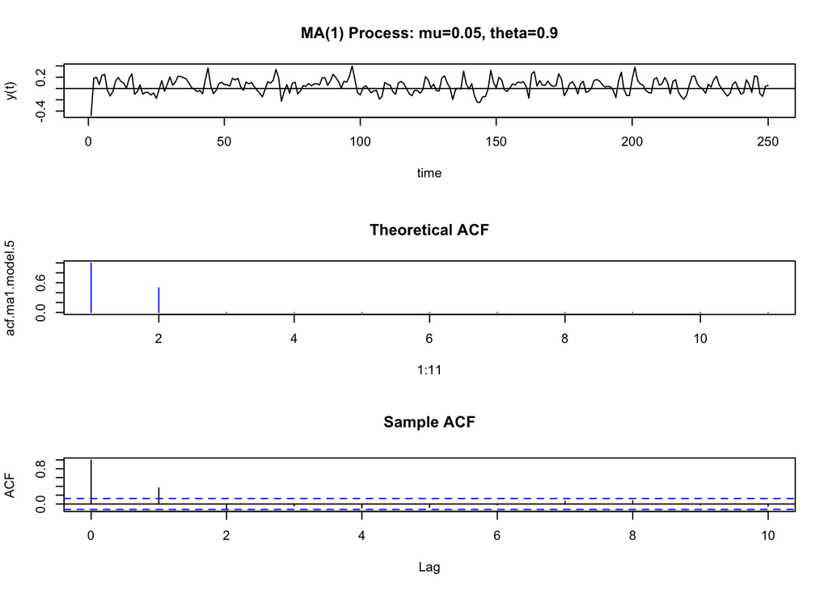

```r
theta = 0.9
mu    = 0.05
ma1.model.5 = list(ma=theta)

set.seed(123)
ma1.sim.5 = mu + arima.sim(model=ma1.model.5, n=250,
                         innov=rnorm(n=250, mean=0, sd=0.1))

acf.ma1.model.5 = ARMAacf(ma=theta, lag.max=10)
par(mfrow=c(3,1))
    plot(ma1.sim.5, main="MA(1) Process: mu=0.05, theta=0.9",xlab="time",ylab="y(t)")
    abline(h=0)
    plot(1:11, acf.ma1.model.5, type="h", col="blue", main="Theoretical ACF")
    tmp=acf(ma1.sim.5, lag.max=10, main="Sample ACF")
```

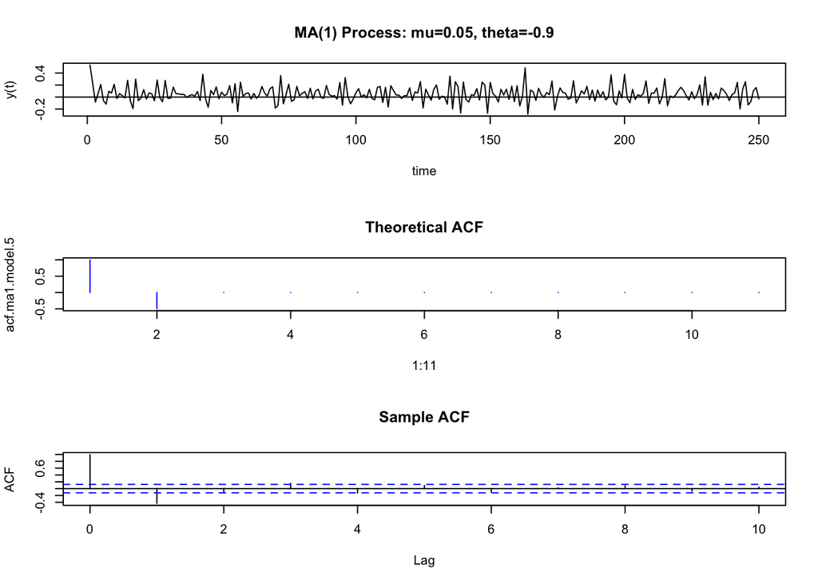

```r
theta = -0.9
mu    = 0.05
ma1.model.5 = list(ma=theta)

set.seed(123)
ma1.sim.5 = mu + arima.sim(model=ma1.model.5, n=250,
                         innov=rnorm(n=250, mean=0, sd=0.1))

acf.ma1.model.5 = ARMAacf(ma=theta, lag.max=10)
par(mfrow=c(3,1))
    plot(ma1.sim.5, main="MA(1) Process: mu=0.05, theta=-0.9",xlab="time",ylab="y(t)")
    abline(h=0)
    plot(1:11, acf.ma1.model.5, type="h", col="blue", main="Theoretical ACF")
    tmp=acf(ma1.sim.5, lag.max=10, main="Sample ACF")
```

1 b) As we know our model is MA(1), so Y(t) is a linear combination of mu, e(t), and e(t-1). Also, the sign of the correlations of two RV with lag 1 (Y(t) and Y(t-1)) is determined by theta. By increasing theta, the first lag on the ACF didn’t change much.

Question 2

2 a)

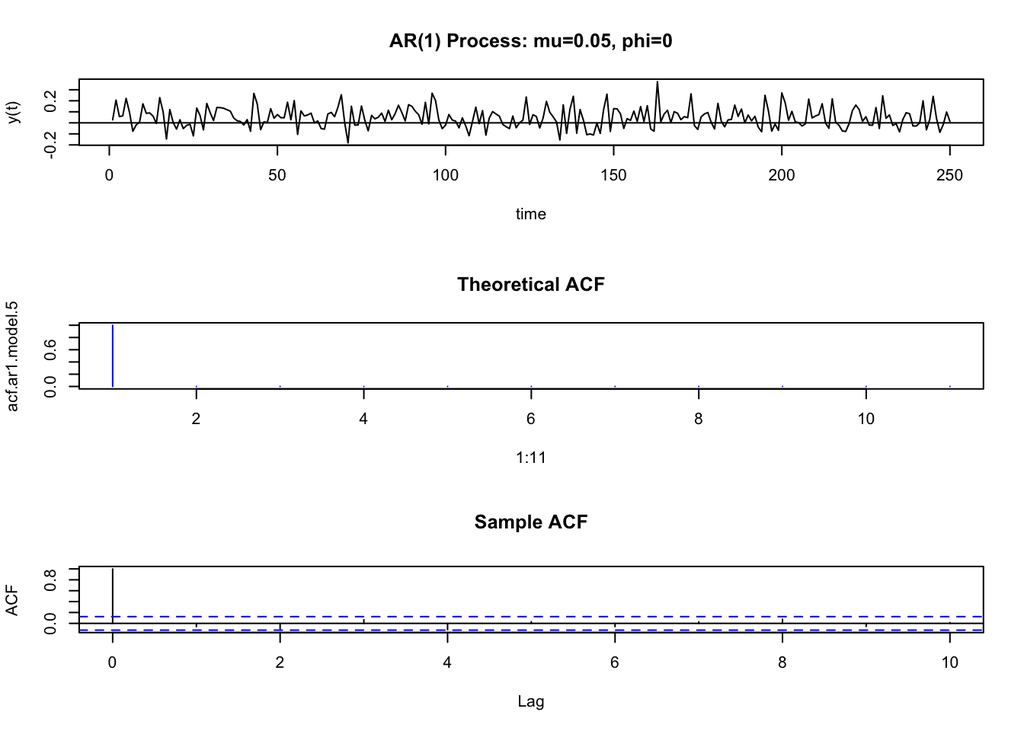

```r
phi = 0
mu  = 0.05
ar1.model.5 = list(ar=phi)

set.seed(123)
ar1.sim.5 = suppressWarnings(mu*(1-phi) + arima.sim(model=ar1.model.5, n = 250,
                             innov=rnorm(n=250, mean=0, sd=0.1)))
acf.ar1.model.5 = ARMAacf(ar=phi, lag.max=10)

par(mfrow=c(3,1))
    plot(ar1.sim.5, main="AR(1) Process: mu=0.05, phi=0",
           xlab="time",ylab="y(t)")
    abline(h=0)
    plot(1:11, acf.ar1.model.5, type="h", col="blue", main="Theoretical ACF")
    tmp=acf(ar1.sim.5, lag.max=10, main="Sample ACF")
```

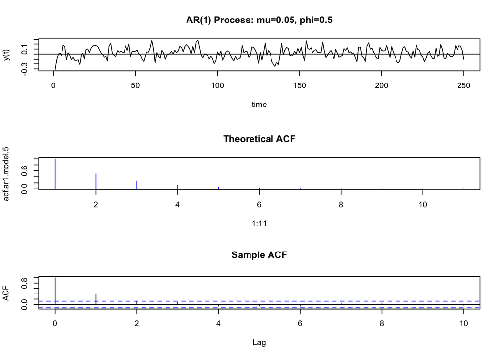

```r
phi = 0.5
mu  = 0.05
ar1.model.5 = list(ar=phi)

set.seed(123)
ar1.sim.5 = mu*(1-phi) + arima.sim(model=ar1.model.5, n = 250,
                             innov=rnorm(n=250, mean=0, sd=0.1))
acf.ar1.model.5 = ARMAacf(ar=phi, lag.max=10)

par(mfrow=c(3,1))
    plot(ar1.sim.5, main="AR(1) Process: mu=0.05, phi=0.5",
           xlab="time",ylab="y(t)")
    abline(h=0)
    plot(1:11, acf.ar1.model.5, type="h", col="blue", main="Theoretical ACF")
    tmp=acf(ar1.sim.5, lag.max=10, main="Sample ACF")
```

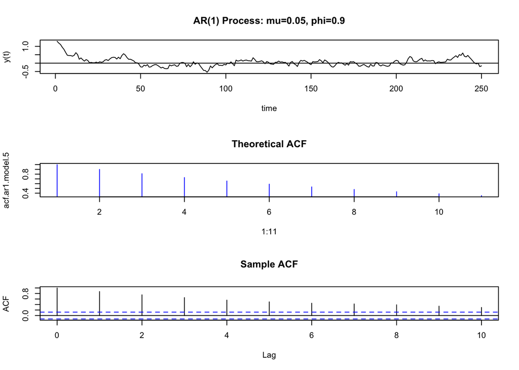

```r
phi = 0.9
mu  = 0.05
ar1.model.5 = list(ar=phi)

set.seed(123)
ar1.sim.5 = mu*(1-phi) + arima.sim(model=ar1.model.5, n = 250,
                             innov=rnorm(n=250, mean=0, sd=0.1))
acf.ar1.model.5 = ARMAacf(ar=phi, lag.max=10)

par(mfrow=c(3,1))
    plot(ar1.sim.5, main="AR(1) Process: mu=0.05, phi=0.9",
           xlab="time",ylab="y(t)")
    abline(h=0)
    plot(1:11, acf.ar1.model.5, type="h", col="blue", main="Theoretical ACF")
    tmp=acf(ar1.sim.5, lag.max=10, main="Sample ACF")
```

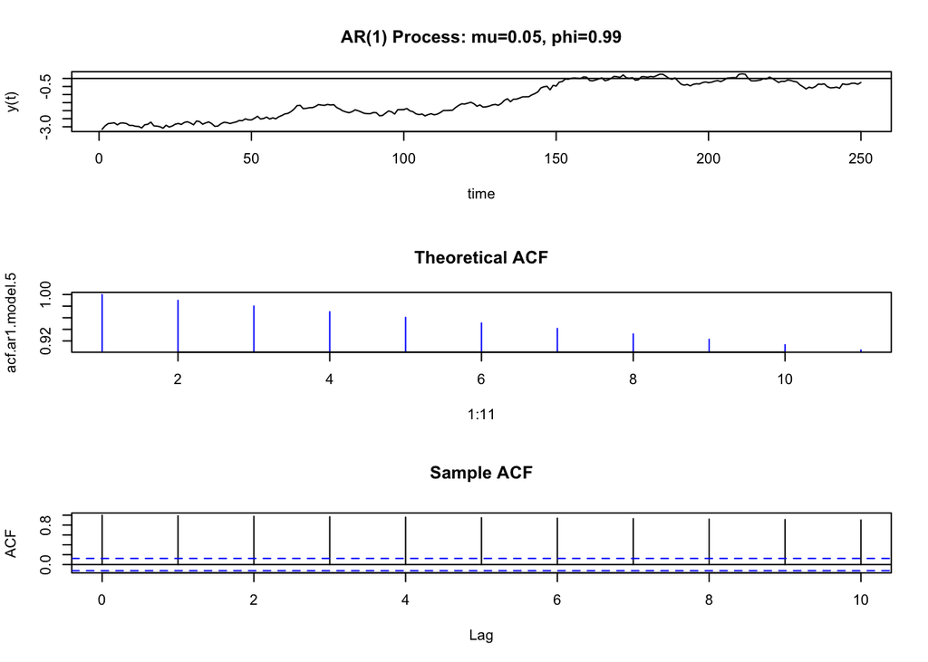

```r
phi = 0.99
mu  = 0.05
ar1.model.5 = list(ar=phi)

set.seed(123)
ar1.sim.5 = mu*(1-phi) + arima.sim(model=ar1.model.5, n = 250,
                             innov=rnorm(n=250, mean=0, sd=0.1))
acf.ar1.model.5 = ARMAacf(ar=phi, lag.max=10)

par(mfrow=c(3,1))
    plot(ar1.sim.5, main="AR(1) Process: mu=0.05, phi=0.99",
           xlab="time",ylab="y(t)")
    abline(h=0)
    plot(1:11, acf.ar1.model.5, type="h", col="blue", main="Theoretical ACF")
    tmp=acf(ar1.sim.5, lag.max=10, main="Sample ACF")
```

2 b) By observing the ACFs, we ifer that the phi effects the correlation, and hence dependence in out process. Also, for large values of phi, the process looks like a non-stationary process. For phi =0, the process will turn to Y(t) = mu + e(t), thus ACF graph doesn’t show any correlation.

R Exercise B

Question 1

```r
options(digits=4, width=70)
library(PerformanceAnalytics)
```

```r
library(zoo)
library(tseries)
VBLTX.prices = get.hist.quote(instrument="vbltx", start="1998-01-01",
                             end="2009-12-31", quote="AdjClose",
                             provider="yahoo", origin="1970-01-01",
                             compression="m", retclass="zoo")
```

[output not shown]

[output not shown]

```
## time series ends   2009-12-01
```

```r
index(VBLTX.prices) = as.yearmon(index(VBLTX.prices))

FMAGX.prices = get.hist.quote(instrument="fmagx", start="1998-01-01",
                             end="2009-12-31", quote="AdjClose",
                             provider="yahoo", origin="1970-01-01",
                             compression="m", retclass="zoo")
```

```
## time series ends   2009-12-01
```

```r
index(FMAGX.prices) = as.yearmon(index(FMAGX.prices))

SBUX.prices = get.hist.quote(instrument="sbux", start="1998-01-01",
                             end="2009-12-31", quote="AdjClose",
                             provider="yahoo", origin="1970-01-01",
                             compression="m", retclass="zoo")
```

```
## time series ends   2009-12-01
```

```r
index(SBUX.prices) = as.yearmon(index(SBUX.prices))
#merged data
lab4Prices.z = merge(VBLTX.prices, FMAGX.prices, SBUX.prices)
colnames(lab4Prices.z) = c("VBLTX", "FMAGX", "SBUX")
lab4Returns.z = diff(log(lab4Prices.z))

start(lab4Returns.z)
```

```
## [1] "Feb 1998"
```

```r
end(lab4Returns.z)
```

```
## [1] "Dec 2009"
```

```r
colnames(lab4Returns.z)
```

```
## [1] "VBLTX" "FMAGX" "SBUX"
```

```r
head(lab4Returns.z)
```

```
##              VBLTX     FMAGX      SBUX
## Feb 1998 -0.004881  0.073069  0.078858
## Mar 1998  0.001037  0.049066  0.135702
## Apr 1998  0.006181  0.011513  0.060219
## May 1998  0.018136 -0.045728 -0.002601
## Jun 1998  0.020749  0.067677  0.107312
## Jul 1998 -0.005911 -0.007508 -0.243824
```

1 a)

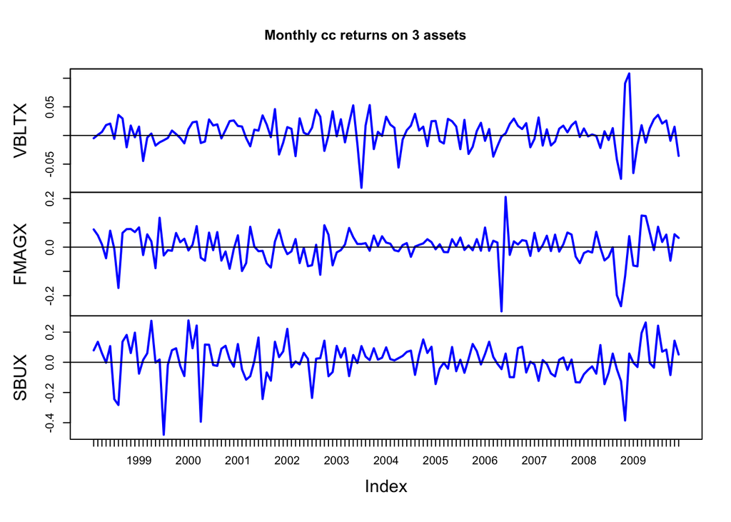

```r
my.panel <- function(...) {
  lines(...)
  abline(h=0)
}
plot(lab4Returns.z, col="blue", lwd=2, main="Monthly cc returns on 3 assets",
     panel=my.panel)
```

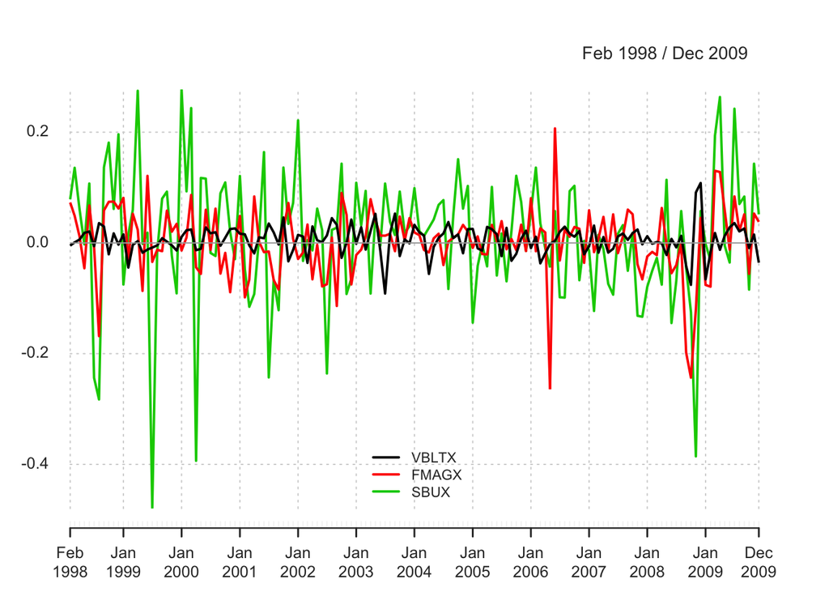

```r
chart.TimeSeries(lab4Returns.z, legend.loc="bottom", main="")
```

We can observe the volatility better by comparing them all on the same graph.

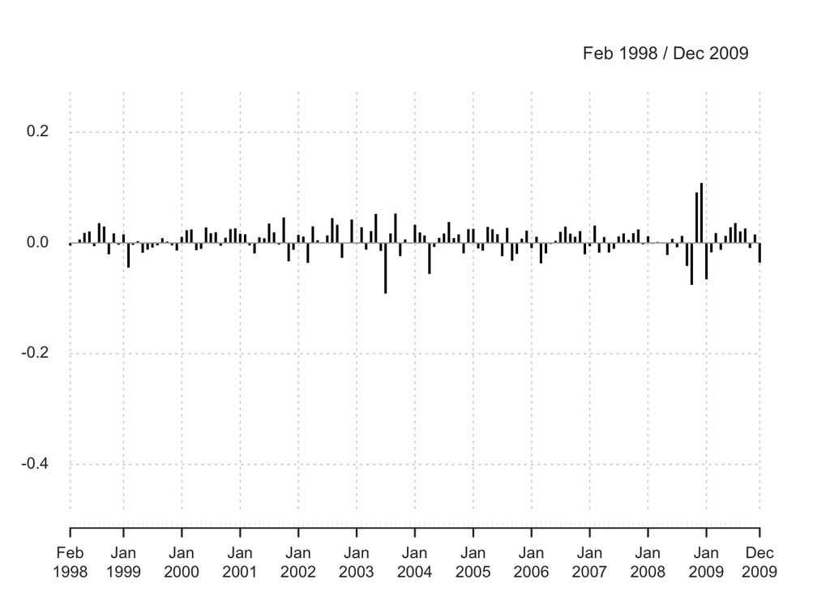

```r
chart.Bar(lab4Returns.z, main="")
```

1 b)

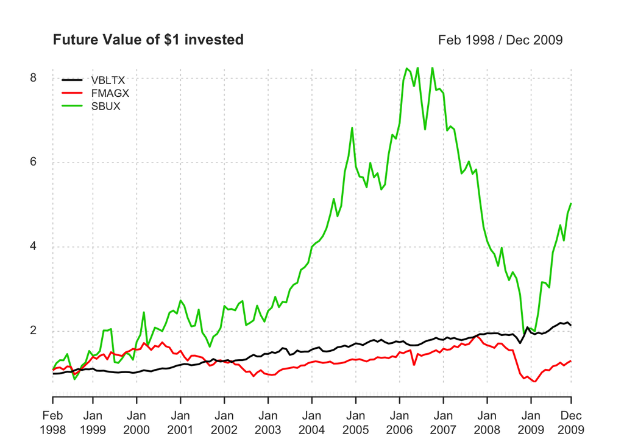

```r
chart.CumReturns(diff(lab4Prices.z)/lag(lab4Prices.z, k=-1),
                 legend.loc="topleft", wealth.index=TRUE,
                 main="Future Value of $1 invested")
```

```r
ret.mat = coredata(lab4Returns.z)
```

Over the investment horizon, SBUX had the best future value, but also had highest volatility VBLTX had steady return. FMAGX had the worst future value.

1 c)

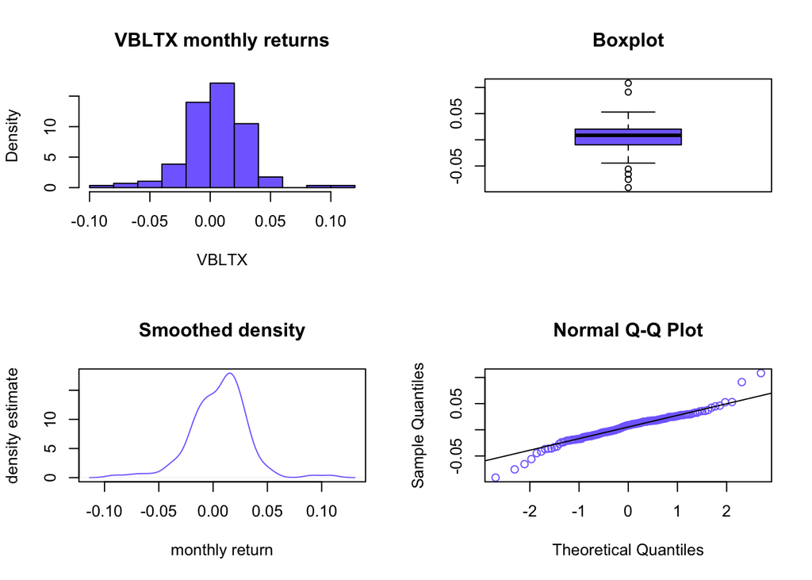

```r
par(mfrow=c(2,2))
    hist(ret.mat[,"VBLTX"],main="VBLTX monthly returns",
         xlab="VBLTX", probability=T, col="slateblue1")
    boxplot(ret.mat[,"VBLTX"],outchar=T, main="Boxplot", col="slateblue1")
    plot(density(ret.mat[,"VBLTX"]),type="l", main="Smoothed density",
           xlab="monthly return", ylab="density estimate", col="slateblue1")
    qqnorm(ret.mat[,"VBLTX"], col="slateblue1")
    qqline(ret.mat[,"VBLTX"])
```

```r
par(mfrow=c(1,1))
```

The distribution is relatively symmetric with fatter tails on the left side as we see it on box-plot and hist density. The Q-Q plot indicates some differences on the tails, but pretty much like normal on the middle.

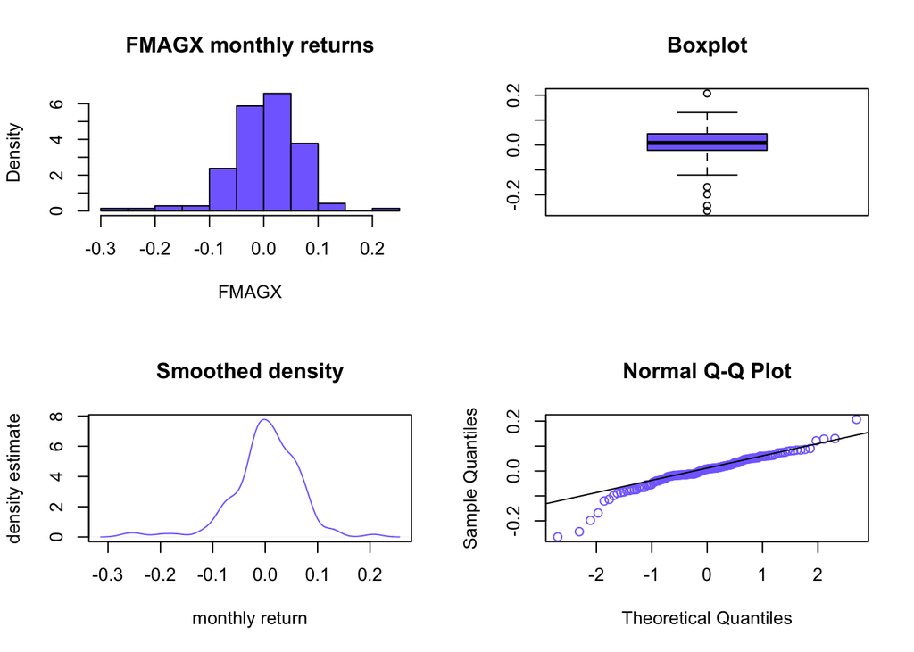

```r
par(mfrow=c(2,2))
    hist(ret.mat[,"FMAGX"],main="FMAGX monthly returns",
         xlab="FMAGX", probability=T, col="slateblue1")
    boxplot(ret.mat[,"FMAGX"],outchar=T, main="Boxplot", col="slateblue1")
    plot(density(ret.mat[,"FMAGX"]),type="l", main="Smoothed density",
         xlab="monthly return", ylab="density estimate", col="slateblue1")
    qqnorm(ret.mat[,"FMAGX"], col="slateblue1")
    qqline(ret.mat[,"FMAGX"])
```

```r
par(mfrow=c(1,1))
```

The distribution doesn’t look normal.(more data on the right, negatively skewed) The Q-Q plot indicates fat tail on the left side than normal, but simillar to normal on the middle.

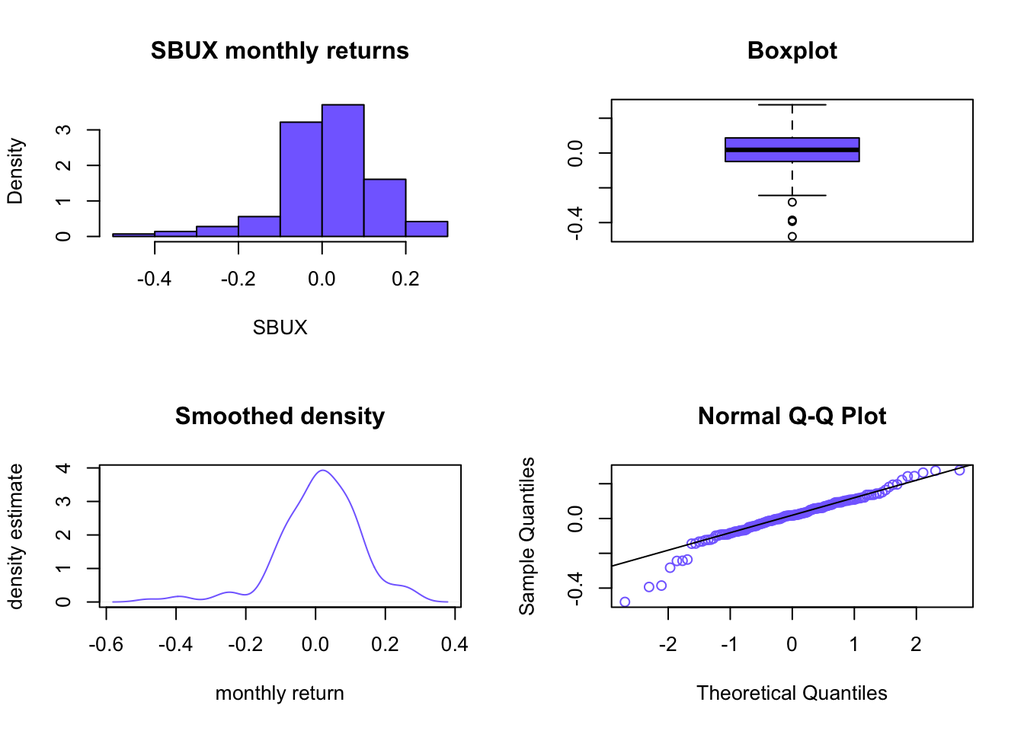

```r
par(mfrow=c(2,2))
    hist(ret.mat[,"SBUX"],main="SBUX monthly returns",
         xlab="SBUX", probability=T, col="slateblue1")
    boxplot(ret.mat[,"SBUX"],outchar=T, main="Boxplot", col="slateblue1")
    plot(density(ret.mat[,"SBUX"]),type="l", main="Smoothed density",
         xlab="monthly return", ylab="density estimate", col="slateblue1")
    qqnorm(ret.mat[,"SBUX"], col="slateblue1")
    qqline(ret.mat[,"SBUX"])
```

```r
par(mfrow=c(1,1))
```

The distribution is not very symmetric with(somehow negatively skewed) The Q-Q plot indicated left tail doesn’t look like normal but right is more simillar

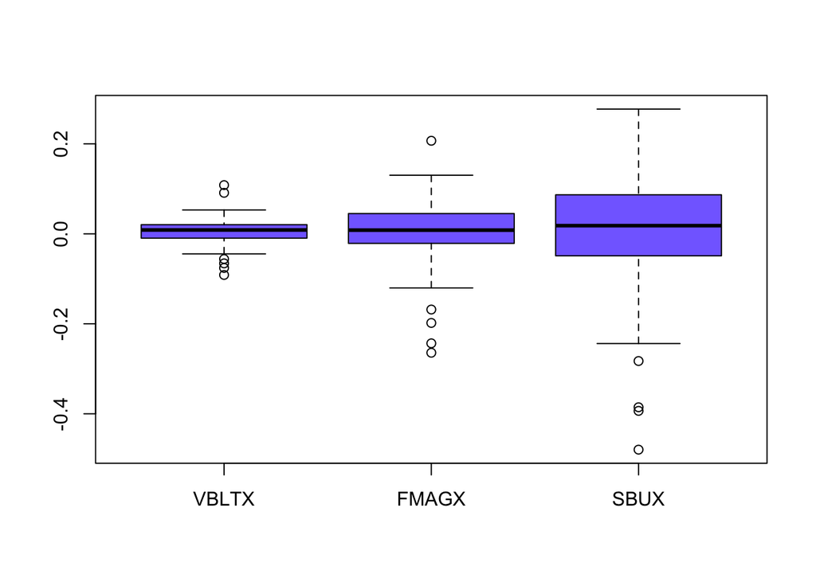

```r
boxplot(ret.mat[,"VBLTX"], ret.mat[,"FMAGX"], ret.mat[,"SBUX"],
        names=colnames(ret.mat), col="slateblue1")
```

This box-plot graph will help us to compare them all together b/c they are on the same scale. As we can see, VBLTX has the lowest volatility, and SBUX has the highest.

1 d)

```r
summary(ret.mat)
```

```
##      VBLTX              FMAGX               SBUX
##  Min.   :-0.09138   Min.   :-0.26430   Min.   :-0.4797
##  1st Qu.:-0.00958   1st Qu.:-0.02124   1st Qu.:-0.0488
##  Median : 0.00855   Median : 0.00825   Median : 0.0182
##  Mean   : 0.00530   Mean   : 0.00186   Mean   : 0.0113
##  3rd Qu.: 0.02038   3rd Qu.: 0.04503   3rd Qu.: 0.0868
##  Max.   : 0.10827   Max.   : 0.20686   Max.   : 0.2773
```

```r
print("Mean")
```

```
## [1] "Mean"
```

```r
apply(ret.mat, 2, mean)
```

```
##    VBLTX    FMAGX     SBUX
## 0.005302 0.001856 0.011318
```

```r
print("var")
```

```
## [1] "var"
```

```r
apply(ret.mat, 2, var)
```

```
##     VBLTX     FMAGX      SBUX
## 0.0006903 0.0041077 0.0142545
```

```r
print("SD")
```

```
## [1] "SD"
```

```r
apply(ret.mat, 2, sd)
```

```
##   VBLTX   FMAGX    SBUX
## 0.02627 0.06409 0.11939
```

```r
print("skewness")
```

```
## [1] "skewness"
```

```r
apply(ret.mat, 2, skewness)
```

```
##   VBLTX   FMAGX    SBUX
## -0.1470 -0.9284 -0.9061
```

```r
print("kurtosis")
```

```
## [1] "kurtosis"
```

```r
apply(ret.mat, 2, kurtosis)
```

```
## VBLTX FMAGX  SBUX
## 2.887 3.398 2.695
```

SBUX has the highest mean, and all the means are positive. Variance of SUBUX is the highest, and VBLTX has the lowest variance which we observed it in the previous parts. Skeweness is negative for all of them. Meaning that distributions are all negatively skewed. Kurtosis (excess) indicates that they all have fatter tails than nomral.

1 e) and f)

```r
# annualized cc mean
12*apply(ret.mat, 2, mean)
```

```
##   VBLTX   FMAGX    SBUX
## 0.06363 0.02227 0.13582
```

```r
# annualized simple mean
exp(12*apply(ret.mat, 2, mean)) - 1
```

```
##   VBLTX   FMAGX    SBUX
## 0.06569 0.02252 0.14548
```

```r
# annualized sd values
sqrt(12)*apply(ret.mat, 2, sd)
```

```
##   VBLTX   FMAGX    SBUX
## 0.09101 0.22202 0.41359
```

1 g)

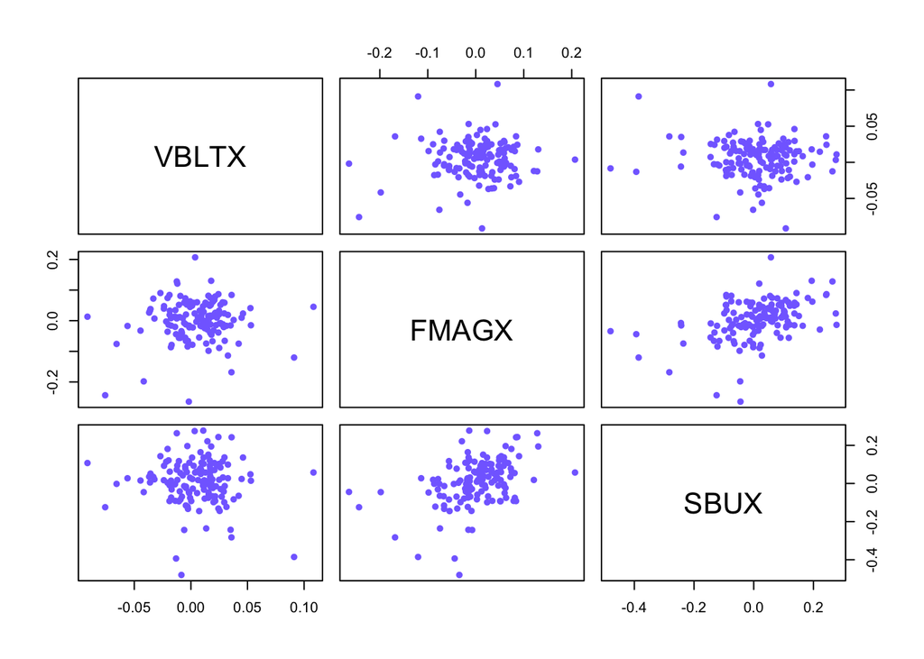

```r
pairs(ret.mat, col="slateblue1", pch=16)
```

No clear relation exists except between FMAGX and SBUX which a linear relationship can be seen.

1 h)

```r
# compute 3 x 3 covariance and correlation matrices
var(ret.mat)
```

```
##            VBLTX     FMAGX       SBUX
## VBLTX  0.0006903 0.0001074 -0.0001761
## FMAGX  0.0001074 0.0041077  0.0032432
## SBUX  -0.0001761 0.0032432  0.0142545
```

```r
cor(ret.mat)
```

```
##          VBLTX   FMAGX     SBUX
## VBLTX  1.00000 0.06376 -0.05614
## FMAGX  0.06376 1.00000  0.42384
## SBUX  -0.05614 0.42384  1.00000
```

cov between VBLTX and FMAGX is positive (positive linear relation) cov between FMAGX and SBUX is positive (positive linear relation) cov between VBLTX and SBUX is negative (negative linear relation)

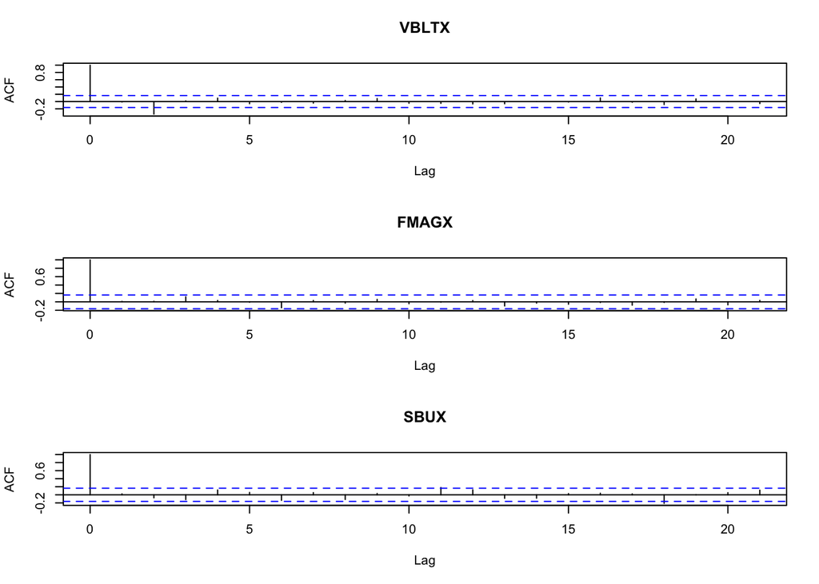

```r
par(mfrow=c(3,1))
    acf.msft = acf(ret.mat[,"VBLTX"], main="VBLTX")
    acf.sbux = acf(ret.mat[,"FMAGX"], main="FMAGX")
    acf.sp500 = acf(ret.mat[,"SBUX"], main="SBUX")
```

```r
par(mfrow=c(1,1))
```

It shows that it is almost uncorrelated for all 3 assets.

2 a)

```r
muhat.vals = apply(ret.mat, 2, mean)
muhat.vals
```

```
##    VBLTX    FMAGX     SBUX
## 0.005302 0.001856 0.011318
```

```r
sigma2hat.vals = apply(ret.mat, 2, var)
sigma2hat.vals
```

```
##     VBLTX     FMAGX      SBUX
## 0.0006903 0.0041077 0.0142545
```

```r
sigmahat.vals = apply(ret.mat, 2, sd)
sigmahat.vals
```

```
##   VBLTX   FMAGX    SBUX
## 0.02627 0.06409 0.11939
```

```r
cov.mat = var(ret.mat)
cov.mat
```

```
##            VBLTX     FMAGX       SBUX
## VBLTX  0.0006903 0.0001074 -0.0001761
## FMAGX  0.0001074 0.0041077  0.0032432
## SBUX  -0.0001761 0.0032432  0.0142545
```

```r
cor.mat = cor(ret.mat)
cor.mat
```

```
##          VBLTX   FMAGX     SBUX
## VBLTX  1.00000 0.06376 -0.05614
## FMAGX  0.06376 1.00000  0.42384
## SBUX  -0.05614 0.42384  1.00000
```

```r
covhat.vals = cov.mat[lower.tri(cov.mat)]
rhohat.vals = cor.mat[lower.tri(cor.mat)]
names(covhat.vals) <- names(rhohat.vals) <-
c("VBLTX,FMAGX","VBLTX,SBUX","FMAGX,SBUX")
covhat.vals
```

```
## VBLTX,FMAGX  VBLTX,SBUX  FMAGX,SBUX
##   0.0001074  -0.0001761   0.0032432
```

```r
rhohat.vals
```

```
## VBLTX,FMAGX  VBLTX,SBUX  FMAGX,SBUX
##     0.06376    -0.05614     0.42384
```

```r
cbind(muhat.vals,sigma2hat.vals,sigmahat.vals)
```

```
##       muhat.vals sigma2hat.vals sigmahat.vals
## VBLTX   0.005302      0.0006903       0.02627
## FMAGX   0.001856      0.0041077       0.06409
## SBUX    0.011318      0.0142545       0.11939
```

```r
cbind(covhat.vals,rhohat.vals)
```

```
##             covhat.vals rhohat.vals
## VBLTX,FMAGX   0.0001074     0.06376
## VBLTX,SBUX   -0.0001761    -0.05614
## FMAGX,SBUX    0.0032432     0.42384
```

As we can see, SBUX has the highest mean and SD. (make sense b/c it’s individual stock) VBLTX has the lowest SD b/c it’s a bond. FAMAGX is a portfolio which mean the lowest.

2 b) c)

```r
# compute estimated standard error for mean
nobs = nrow(ret.mat)
nobs
```

```
## [1] 143
```

```r
se.muhat = sigmahat.vals/sqrt(nobs)
se.muhat
```

```
##    VBLTX    FMAGX     SBUX
## 0.002197 0.005360 0.009984
```

```r
cbind(muhat.vals,se.muhat)
```

```
##       muhat.vals se.muhat
## VBLTX   0.005302 0.002197
## FMAGX   0.001856 0.005360
## SBUX    0.011318 0.009984
```

```r
# compute approx 95% confidence intervals
mu.lower = muhat.vals - 2*se.muhat
mu.upper = muhat.vals + 2*se.muhat
cbind(mu.lower,mu.upper)
```

```
##        mu.lower mu.upper
## VBLTX  0.000908 0.009696
## FMAGX -0.008863 0.012575
## SBUX  -0.008650 0.031286
```

```r
# compute estimated standard errors for variance and sd
se.sigma2hat = sigma2hat.vals/sqrt(nobs/2)
se.sigma2hat
```

```
##     VBLTX     FMAGX      SBUX
## 8.163e-05 4.858e-04 1.686e-03
```

```r
se.sigmahat = sigmahat.vals/sqrt(2*nobs)
se.sigmahat
```

```
##    VBLTX    FMAGX     SBUX
## 0.001554 0.003790 0.007060
```

```r
cbind(sigma2hat.vals,se.sigma2hat)
```

```
##       sigma2hat.vals se.sigma2hat
## VBLTX      0.0006903    8.163e-05
## FMAGX      0.0041077    4.858e-04
## SBUX       0.0142545    1.686e-03
```

```r
cbind(sigmahat.vals,se.sigmahat)
```

```
##       sigmahat.vals se.sigmahat
## VBLTX       0.02627    0.001554
## FMAGX       0.06409    0.003790
## SBUX        0.11939    0.007060
```

```r
# compute approx 95% confidence intervals
sigma2.lower = sigma2hat.vals - 2*se.sigma2hat
sigma2.upper = sigma2hat.vals + 2*se.sigma2hat
cbind(sigma2.lower,sigma2.upper)
```

```
##       sigma2.lower sigma2.upper
## VBLTX     0.000527    0.0008535
## FMAGX     0.003136    0.0050793
## SBUX      0.010883    0.0176260
```

```r
sigma.lower = sigmahat.vals - 2*se.sigmahat
sigma.upper = sigmahat.vals + 2*se.sigmahat
cbind(sigma.lower,sigma.upper)
```

```
##       sigma.lower sigma.upper
## VBLTX     0.02317     0.02938
## FMAGX     0.05651     0.07167
## SBUX      0.10527     0.13351
```

```r
# compute estimated standard errors for correlation
se.rhohat = (1-rhohat.vals^2)/sqrt(nobs)
se.rhohat
```

```
## VBLTX,FMAGX  VBLTX,SBUX  FMAGX,SBUX
##     0.08328     0.08336     0.06860
```

```r
cbind(rhohat.vals,se.rhohat)
```

```
##             rhohat.vals se.rhohat
## VBLTX,FMAGX     0.06376   0.08328
## VBLTX,SBUX     -0.05614   0.08336
## FMAGX,SBUX      0.42384   0.06860
```

```r
# compute approx 95% confidence intervals
rho.lower = rhohat.vals - 2*se.rhohat
rho.upper = rhohat.vals + 2*se.rhohat
cbind(rho.lower,rho.upper)
```

```
##             rho.lower rho.upper
## VBLTX,FMAGX   -0.1028    0.2303
## VBLTX,SBUX    -0.2229    0.1106
## FMAGX,SBUX     0.2866    0.5610
```

The variance and SD are estimated more precisely. The mean is not estimated precisely. the cor of VBLTX is not very precise. the cor between FMAGX and SBUX is precise. The 95% for mean of SBUX and FMAGX have negative and positive values and it’s relatively wide, so it’s not good estimate The 95% for SD and var is not very wide, thus it give us more precise estimate The third line in the correkation estimate is narrow.

2 d)

```r
Value.at.Risk = function(x,p=0.05,w=100000) {
    x = as.matrix(x)
    q = apply(x, 2, mean) + apply(x, 2, sd)*qnorm(p)
    VaR = (exp(q) - 1)*w
    VaR
}

Value.at.Risk(ret.mat,p=0.05,w=100000)
```

```
##  VBLTX  FMAGX   SBUX
##  -3720  -9838 -16895
```

```r
Value.at.Risk(ret.mat,p=0.01,w=100000)
```

```
##  VBLTX  FMAGX   SBUX
##  -5429 -13692 -23389
```

As we can see, the largest VaR is for SBUX( makes sense). VBLTX has the lowest VaR value